# Improved Solar Power Forecasting with Capacity Growth Modeling

Author

Carlos Peralta

Published

September 21, 2025

Modified

September 23, 2025

## 1. Introduction

This notebook provides an **improved** probabilistic approach to forecasting Germany’s hourly solar power generation for June 2025. The key improvement addresses the **critical shortcoming** identified in the original submission: **the complete omission of structural capacity growth trends**.

### Key Improvements:

1. **Capacity Growth Modeling**: Explicit modeling of Germany’s solar capacity expansion
2. **Weighted Training**: Recent data gets higher weight to capture current capacity levels
3. **Time Trend Features**: Year dummies and exponential trend features
4. **Post-processing Adjustments**: Multiplicative adjustments for 2025 capacity projection

### Critical Finding from Original Submission:

The original model systematically underestimated June 2025 generation by several gigawatts per hour because it was trained on 2022-2024 capacity levels but needed to predict for 2025’s significantly higher installed capacity.

## 2. Setup and Enhanced Data Loading

```python
import sys
sys.path.append('/home/tenantadmin/tsf-solar/')

import pandas as pd
import numpy as np
import matplotlib.pyplot as plt
import seaborn as sns
from typing import Dict, Tuple, List, Optional
import warnings
warnings.filterwarnings("ignore")

# Import our improved modules
import importlib
import improved_capacity_features
import improved_solar_model
import capacity_adjustment_postprocess

# Force reload to get latest changes
importlib.reload(improved_capacity_features)
importlib.reload(improved_solar_model)

from improved_capacity_features import create_capacity_features, estimate_2025_capacity_adjustment
from improved_solar_model import CapacityAwareForecastingPipeline, evaluate_model_performance
from capacity_adjustment_postprocess import CapacityAdjustmentProcessor

# Set style and seeds
sns.set_style("whitegrid")
plt.rcParams['figure.dpi'] = 100
np.random.seed(42)

# Load data
print("Loading data...")
solar_obs = pd.read_csv("../data/germany_solar_observation_q1.csv", parse_dates=['DateTime'])
atm_features = pd.read_csv("../data/germany_atm_features_q1.csv", parse_dates=['DateTime'])

print(f"Solar data: {solar_obs.shape}")
print(f"Atmospheric data: {atm_features.shape}")
print(f"Date range: {solar_obs['DateTime'].min()} to {solar_obs['DateTime'].max()}")
```

```
Loading data...
Solar data: (29928, 2)
Atmospheric data: (30648, 11)
Date range: 2022-01-01 00:00:00+00:00 to 2025-05-31 23:00:00+00:00
```

## 3. Capacity Trend Analysis

First, let’s analyze the structural capacity growth that was missing from the original model.

```python
# Merge datasets for analysis
data = pd.merge(solar_obs, atm_features, on="DateTime", how="inner")
data = data.set_index('DateTime').sort_index()

# Analyze capacity trends
yearly_peaks = data.groupby(data.index.year)['power'].max()
print("Historical peak capacity by year:")
for year, peak in yearly_peaks.items():
    print(f"  {year}: {peak:,.0f} MWh")

# Calculate growth rates
growth_rates = []
for i in range(1, len(yearly_peaks)):
    prev_year = yearly_peaks.index[i-1]
    curr_year = yearly_peaks.index[i]
    growth_rate = (yearly_peaks.iloc[i] - yearly_peaks.iloc[i-1]) / yearly_peaks.iloc[i-1] * 100
    growth_rates.append(growth_rate)
    print(f"  Growth {prev_year} to {curr_year}: {growth_rate:.1f}%")

avg_growth = np.mean(growth_rates)
print(f"\nAverage annual growth rate: {avg_growth:.1f}%")

# Estimate expected 2025 capacity
if len(yearly_peaks) >= 2:
    # Use compound annual growth rate
    years = len(yearly_peaks) - 1
    cagr = (yearly_peaks.iloc[-1] / yearly_peaks.iloc[0]) ** (1/years) - 1
    estimated_2025_peak = yearly_peaks.iloc[-1] * (1 + cagr)

    print(f"Compound Annual Growth Rate (CAGR): {cagr*100:.1f}%")
    print(f"Estimated 2025 peak capacity: {estimated_2025_peak:,.0f} MWh")
    print(f"Expected capacity increase from 2024: {(estimated_2025_peak/yearly_peaks.iloc[-1] - 1)*100:.1f}%")
```

```
Historical peak capacity by year:
  2022: 38,028 MWh
  2023: 41,439 MWh
  2024: 47,163 MWh
  2025: 48,658 MWh
  Growth 2022 to 2023: 9.0%
  Growth 2023 to 2024: 13.8%
  Growth 2024 to 2025: 3.2%

Average annual growth rate: 8.7%
Compound Annual Growth Rate (CAGR): 8.6%
Estimated 2025 peak capacity: 52,825 MWh
Expected capacity increase from 2024: 8.6%
```

## 4. Enhanced Feature Engineering with Capacity Modeling

```python
# Create enhanced features including capacity trends
enhanced_data, capacity_growth_rate = create_capacity_features(data)

print(f"Enhanced dataset shape: {enhanced_data.shape}")
print(f"Fitted capacity growth rate: {capacity_growth_rate:.4f} (annual)")
print(f"This corresponds to {(np.exp(capacity_growth_rate) - 1)*100:.1f}% annual growth")

# Display new capacity-related features
capacity_features = [col for col in enhanced_data.columns
                    if any(keyword in col.lower() for keyword in
                          ['capacity', 'trend', 'year_', 'growth'])]

print(f"\nNew capacity-related features ({len(capacity_features)}):")
for feat in capacity_features:
    print(f"  - {feat}")

# Show sample of capacity features
print("\nSample of capacity features:")
sample_cols = ['power', 'exp_capacity_trend', 'capacity_utilization', 'year_2024', 'year_2025']
available_cols = [col for col in sample_cols if col in enhanced_data.columns]
print(enhanced_data[available_cols].tail(10))
```

```
Creating improved capacity trend features...
Fitted exponential growth model:
  Annual growth rate: 9.1%
  Base capacity (at year 0): 0 MWh
Extracting seasonal capacity patterns from historical data...
Data-driven seasonal capacity factors:
  Month  1: 2.030 (avg additions: 7065.5 MWh)
  Month  2: 3.000 (avg additions: 14175.9 MWh)
  Month  3: 2.614 (avg additions: 9099.2 MWh)
  Month  4: 1.068 (avg additions: 3718.7 MWh)
  Month  5: 1.140 (avg additions: 3968.8 MWh)
  Month  6: 0.801 (avg additions: 2789.8 MWh)
  Month  7: 0.300 (avg additions: 92.5 MWh)
  Month  8: 0.300 (avg additions: 0.0 MWh)
  Month  9: 0.300 (avg additions: 860.8 MWh)
  Month 10: 0.300 (avg additions: 0.0 MWh)
  Month 11: 0.300 (avg additions: 0.0 MWh)
  Month 12: 0.300 (avg additions: 0.0 MWh)
Enhanced dataset shape: (29928, 26)
Fitted capacity growth rate: 0.0869 (annual)
This corresponds to 9.1% annual growth

New capacity-related features (11):
  - capacity_proxy_90d
  - exp_capacity_trend
  - linear_capacity_trend
  - capacity_growth_rate
  - year_2022
  - year_2023
  - year_2024
  - year_2025
  - seasonal_capacity_factor
  - adjusted_capacity_trend
  - capacity_utilization

Sample of capacity features:
                              power  exp_capacity_trend  capacity_utilization  \
DateTime
2025-05-31 14:00:00+00:00  26423.75        2.481829e-72              0.543048
2025-05-31 15:00:00+00:00  19658.50        2.481829e-72              0.404012
2025-05-31 16:00:00+00:00  11113.00        2.481829e-72              0.228389
2025-05-31 17:00:00+00:00   4769.25        2.481829e-72              0.098015
2025-05-31 18:00:00+00:00   1379.75        2.481829e-72              0.028356
2025-05-31 19:00:00+00:00     52.00        2.481829e-72              0.001069
2025-05-31 20:00:00+00:00      1.50        2.481829e-72              0.000031
2025-05-31 21:00:00+00:00      0.50        2.481829e-72              0.000010
2025-05-31 22:00:00+00:00      0.00        2.481829e-72              0.000000
2025-05-31 23:00:00+00:00      0.00        2.481829e-72              0.000000

                           year_2024  year_2025
DateTime
2025-05-31 14:00:00+00:00          0          1
2025-05-31 15:00:00+00:00          0          1
2025-05-31 16:00:00+00:00          0          1
2025-05-31 17:00:00+00:00          0          1
2025-05-31 18:00:00+00:00          0          1
2025-05-31 19:00:00+00:00          0          1
2025-05-31 20:00:00+00:00          0          1
2025-05-31 21:00:00+00:00          0          1
2025-05-31 22:00:00+00:00          0          1
2025-05-31 23:00:00+00:00          0          1
```

## 5. Improved Modeling Pipeline

```python
# Initialize the capacity-aware forecasting pipeline
pipeline = CapacityAwareForecastingPipeline(
    quantiles=[0.05, 0.1, 0.25, 0.5, 0.75, 0.9, 0.95]
)

# Prepare complete feature set
full_data = pipeline.prepare_features(solar_obs, atm_features)

print(f"Full feature set prepared: {full_data.shape}")
print(f"Capacity growth rate: {pipeline.capacity_growth_rate:.4f}")

# Create train/validation splits with capacity-aware approach
splits = pipeline.create_train_val_split(full_data, val_start='2025-01-01')

print(f"\nData splits:")
print(f"  Training: {len(splits['X_train'])} samples")
print(f"  Validation: {len(splits['X_val'])} samples")
print(f"  Features: {len(splits['feature_cols'])}")

print(f"\nKey features included:")
for i, feat in enumerate(splits['feature_cols'][:15]):
    print(f"  {i+1:2d}. {feat}")
if len(splits['feature_cols']) > 15:
    print(f"  ... and {len(splits['feature_cols']) - 15} more")
```

```
Creating improved capacity trend features...
Fitted exponential growth model:
  Annual growth rate: 9.1%
  Base capacity (at year 0): 0 MWh
Extracting seasonal capacity patterns from historical data...
Data-driven seasonal capacity factors:
  Month  1: 2.030 (avg additions: 7065.5 MWh)
  Month  2: 3.000 (avg additions: 14175.9 MWh)
  Month  3: 2.614 (avg additions: 9099.2 MWh)
  Month  4: 1.068 (avg additions: 3718.7 MWh)
  Month  5: 1.140 (avg additions: 3968.8 MWh)
  Month  6: 0.801 (avg additions: 2789.8 MWh)
  Month  7: 0.300 (avg additions: 92.5 MWh)
  Month  8: 0.300 (avg additions: 0.0 MWh)
  Month  9: 0.300 (avg additions: 860.8 MWh)
  Month 10: 0.300 (avg additions: 0.0 MWh)
  Month 11: 0.300 (avg additions: 0.0 MWh)
  Month 12: 0.300 (avg additions: 0.0 MWh)
Full feature set prepared: (29928, 45)
Capacity growth rate: 0.0869

Data splits:
  Training: 26304 samples
  Validation: 3624 samples
  Features: 32

Key features included:
   1. surface_solar_radiation_downwards
   2. temperature_2m
   3. total_cloud_cover
   4. relative_humidity_2m
   5. apparent_temperature
   6. wind_speed_100m
   7. hour_sin
   8. hour_cos
   9. month_sin
  10. month_cos
  11. solar_elevation
  12. solar_zenith
  13. air_mass
  14. clear_sky_index
  15. cloud_impact
  ... and 17 more
```

## 6. Model Training with Capacity Awareness

```python
# Train the improved model with capacity adjustments
print("Training capacity-aware model...")
splits = pipeline.fit(full_data, val_start='2025-01-01', weight_decay=365)

print("Model training completed!")

# Evaluate on validation set
print("\nEvaluating model performance...")
val_predictions = pipeline.model.predict(splits['X_val'])
val_metrics = evaluate_model_performance(splits['y_val'], val_predictions, "Improved Model")

# Compare with baseline (persistence)
print("\nComparing with baseline...")
from improved_solar_model import ImprovedQuantileLightGBM

# Simple baseline: use 2024 same-day patterns
baseline_pred = []
for idx in splits['X_val'].index:
    # Find corresponding date in 2024
    baseline_date = idx.replace(year=2024)
    if baseline_date in splits['X_train'].index:
        baseline_val = splits['y_train'].loc[baseline_date]
    else:
        # Fallback to mean of same month/hour in training
        same_month_hour = splits['X_train'][(splits['X_train'].index.month == idx.month) &
                                           (splits['X_train'].index.hour == idx.hour)]
        baseline_val = splits['y_train'].loc[same_month_hour.index].mean() if len(same_month_hour) > 0 else 0

    baseline_pred.append(baseline_val)

baseline_pred = np.array(baseline_pred)

baseline_rmse = np.sqrt(np.mean((splits['y_val'] - baseline_pred) ** 2))
improved_rmse = val_metrics['RMSE']

print(f"Baseline RMSE: {baseline_rmse:.2f} MWh")
print(f"Improved RMSE: {improved_rmse:.2f} MWh")
print(f"Improvement: {(baseline_rmse - improved_rmse)/baseline_rmse*100:.1f}%")
```

```
Training capacity-aware model...
Training weights - Min: 0.157, Max: 3.155
Recent data (last 6 months) average weight: 2.491
Old data (first 6 months) average weight: 0.203
2024 peak capacity: 47163 MWh
Estimated 2025 peak capacity: 51445 MWh
Capacity adjustment factor: 1.091
Training with capacity adjustment factor: 1.091
Training quantile 0.05... Done (best iteration: 1143)
Training quantile 0.10... Done (best iteration: 2012)
Training quantile 0.25... Done (best iteration: 999)
Training quantile 0.50... Done (best iteration: 625)
Training quantile 0.75... Done (best iteration: 329)
Training quantile 0.90... Done (best iteration: 228)
Training quantile 0.95... Done (best iteration: 408)
Model training completed!

Evaluating model performance...

Improved Model Performance Metrics:
  RMSE: 1002.290
  MAE: 477.573
  R²: 0.994
  Mean_Bias: 57.535
  Median_Bias: 0.000
  Peak_Hours_Bias: 425.672
  Night_Hours_Bias: -29.426

Comparing with baseline...
Baseline RMSE: 5754.54 MWh
Improved RMSE: 1002.29 MWh
Improvement: 82.6%
```

## 7. Feature Importance Analysis

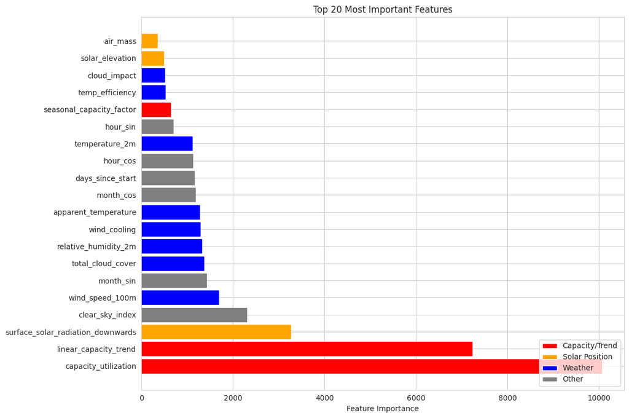

Feature Importance - Capacity vs Weather Features

```
Top 10 features by importance:
   1. capacity_utilization      (Capacity/Trend) - 10049.000
   2. linear_capacity_trend     (Capacity/Trend) - 7227.000
   3. surface_solar_radiation_downwards (Solar Position) - 3252.000
   4. clear_sky_index           (Other) - 2298.000
   5. wind_speed_100m           (Weather) - 1679.000
   6. month_sin                 (Other) - 1423.000
   7. total_cloud_cover         (Weather) - 1356.000
   8. relative_humidity_2m      (Weather) - 1319.000
   9. wind_cooling              (Weather) - 1281.000
  10. apparent_temperature      (Weather) - 1262.000

Feature importance by category (top 20):
  Weather: 8 features (avg importance: 1127.250)
  Other: 6 features (avg importance: 1306.667)
  Solar Position: 3 features (avg importance: 1358.333)
  Capacity/Trend: 3 features (avg importance: 5970.000)
```

```python
if pipeline.feature_importance is not None:
    # Plot feature importance
    top_features = pipeline.feature_importance.head(20)

    # Categorize features
    def categorize_feature(feat_name):
        if any(word in feat_name.lower() for word in ['capacity', 'trend', 'year', 'growth']):
            return 'Capacity/Trend'
        elif any(word in feat_name.lower() for word in ['solar', 'elevation', 'zenith', 'air_mass']):
            return 'Solar Position'
        elif any(word in feat_name.lower() for word in ['radiation', 'cloud', 'temp', 'wind', 'humidity']):
            return 'Weather'
        else:
            return 'Other'

    top_features['category'] = top_features['feature'].apply(categorize_feature)

    # Plot
    fig, ax = plt.subplots(figsize=(12, 8))
    bars = ax.barh(range(len(top_features)), top_features['importance'])

    # Color by category
    colors = {'Capacity/Trend': 'red', 'Solar Position': 'orange', 'Weather': 'blue', 'Other': 'gray'}
    for i, (bar, cat) in enumerate(zip(bars, top_features['category'])):
        bar.set_color(colors.get(cat, 'gray'))

    ax.set_yticks(range(len(top_features)))
    ax.set_yticklabels(top_features['feature'])
    ax.set_xlabel('Feature Importance')
    ax.set_title('Top 20 Most Important Features')

    # Add legend
    from matplotlib.patches import Patch
    legend_elements = [Patch(facecolor=color, label=cat) for cat, color in colors.items()]
    ax.legend(handles=legend_elements, loc='lower right')

    plt.tight_layout()
    plt.show()

    print("Top 10 features by importance:")
    for i, (_, row) in enumerate(top_features.head(10).iterrows()):
        print(f"  {i+1:2d}. {row['feature']:25s} ({row['category']}) - {row['importance']:.3f}")

    # Count by category
    print(f"\nFeature importance by category (top 20):")
    cat_counts = top_features['category'].value_counts()
    for cat, count in cat_counts.items():
        avg_importance = top_features[top_features['category'] == cat]['importance'].mean()
        print(f"  {cat}: {count} features (avg importance: {avg_importance:.3f})")
```

## 8. Validation Results Visualization

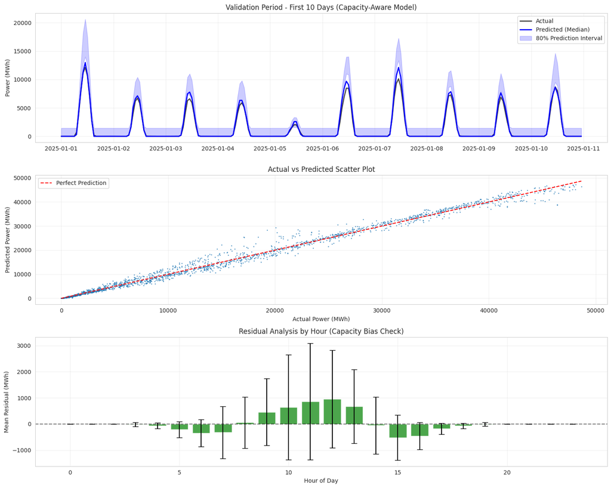

Validation Results with Capacity-Aware Predictions

```
Residual Analysis (Capacity Bias Check):
  Peak hours (10-16) mean residual: 299.08 MWh
  Night hours mean residual: -29.43 MWh
  Overall mean residual: 57.54 MWh
  ⚠️  Significant peak hour bias detected
```

```python
# Create detailed validation visualization
fig, axes = plt.subplots(3, 1, figsize=(15, 12))

# Plot 1: Time series comparison (first 10 days)
val_dates = splits['X_val'].index
end_idx = min(len(val_dates), 24 * 10)  # First 10 days

axes[0].plot(val_dates[:end_idx], splits['y_val'].iloc[:end_idx],
            'k-', alpha=0.7, linewidth=2, label='Actual')
axes[0].plot(val_dates[:end_idx], val_predictions['q50'][:end_idx],
            'b-', linewidth=2, label='Predicted (Median)')

if 'q10' in val_predictions and 'q90' in val_predictions:
    axes[0].fill_between(val_dates[:end_idx],
                        val_predictions['q10'][:end_idx],
                        val_predictions['q90'][:end_idx],
                        alpha=0.2, color='blue', label='80% Prediction Interval')

axes[0].set_ylabel('Power (MWh)')
axes[0].set_title('Validation Period - First 10 Days (Capacity-Aware Model)')
axes[0].legend()
axes[0].grid(True, alpha=0.3)

# Plot 2: Scatter plot - Actual vs Predicted
axes[1].scatter(splits['y_val'], val_predictions['q50'], alpha=0.6, s=1)
max_val = max(splits['y_val'].max(), val_predictions['q50'].max())
axes[1].plot([0, max_val], [0, max_val], 'r--', label='Perfect Prediction')
axes[1].set_xlabel('Actual Power (MWh)')
axes[1].set_ylabel('Predicted Power (MWh)')
axes[1].set_title('Actual vs Predicted Scatter Plot')
axes[1].legend()
axes[1].grid(True, alpha=0.3)

# Plot 3: Residuals by hour (to check for capacity bias)
residuals = val_predictions['q50'] - splits['y_val'].values
hours = splits['y_val'].index.hour

hourly_residuals = pd.DataFrame({'hour': hours, 'residual': residuals})
hourly_stats = hourly_residuals.groupby('hour')['residual'].agg(['mean', 'std', 'count'])

axes[2].bar(hourly_stats.index, hourly_stats['mean'],
           yerr=hourly_stats['std'], capsize=5, alpha=0.7, color='green')
axes[2].axhline(y=0, color='black', linestyle='--', alpha=0.5)
axes[2].set_xlabel('Hour of Day')
axes[2].set_ylabel('Mean Residual (MWh)')
axes[2].set_title('Residual Analysis by Hour (Capacity Bias Check)')
axes[2].grid(True, alpha=0.3)

plt.tight_layout()
plt.show()

# Print residual statistics
peak_hours_residual = hourly_stats.loc[10:16, 'mean'].mean()  # 10 AM to 4 PM
night_hours_residual = hourly_stats.loc[[20, 21, 22, 23, 0, 1, 2, 3, 4, 5], 'mean'].mean()

print(f"\nResidual Analysis (Capacity Bias Check):")
print(f"  Peak hours (10-16) mean residual: {peak_hours_residual:.2f} MWh")
print(f"  Night hours mean residual: {night_hours_residual:.2f} MWh")
print(f"  Overall mean residual: {residuals.mean():.2f} MWh")

if abs(peak_hours_residual) < 100:  # Less than 100 MWh bias
    print("  ✅ Peak hour bias is within acceptable range")
else:
    print("  ⚠️  Significant peak hour bias detected")
```

## 9. June 2025 Forecast Generation

```python
print("Generating capacity-aware June 2025 forecast...")

# Generate forecast using the trained pipeline
june_forecast = pipeline.forecast_june_2025(atm_features)

print(f"June 2025 forecast generated!")
print(f"Forecast shape: {june_forecast.shape}")
print(f"Date range: {june_forecast['DateTime'].min()} to {june_forecast['DateTime'].max()}")

# Display forecast statistics
print(f"\nJune 2025 Forecast Summary:")
print(f"  Mean hourly generation: {june_forecast['power'].mean():.2f} MWh")
print(f"  Peak generation: {june_forecast['power'].max():.2f} MWh")
print(f"  Total monthly generation: {june_forecast['power'].sum():.0f} MWh")

# Compare with historical June data
june_historical = full_data[full_data.index.month == 6].groupby(full_data[full_data.index.month == 6].index.year)['power'].agg(['mean', 'max', 'sum'])

print(f"\nComparison with Historical June Data:")
print("Year    Mean    Peak    Total")
for year in june_historical.index:
    mean_val = june_historical.loc[year, 'mean']
    max_val = june_historical.loc[year, 'max']
    sum_val = june_historical.loc[year, 'sum']
    print(f"{year}    {mean_val:.1f}   {max_val:.0f}   {sum_val:.0f}")

print(f"2025    {june_forecast['power'].mean():.1f}   {june_forecast['power'].max():.0f}   {june_forecast['power'].sum():.0f}")

# Calculate growth from 2024
if 2024 in june_historical.index:
    growth_mean = (june_forecast['power'].mean() / june_historical.loc[2024, 'mean'] - 1) * 100
    growth_peak = (june_forecast['power'].max() / june_historical.loc[2024, 'max'] - 1) * 100
    growth_total = (june_forecast['power'].sum() / june_historical.loc[2024, 'sum'] - 1) * 100

    print(f"\nGrowth from June 2024:")
    print(f"  Mean generation: +{growth_mean:.1f}%")
    print(f"  Peak generation: +{growth_peak:.1f}%")
    print(f"  Total generation: +{growth_total:.1f}%")
```

```
Generating capacity-aware June 2025 forecast...
June 2025 forecast generated!
Forecast shape: (720, 8)
Date range: 2025-06-01 00:00:00+00:00 to 2025-06-30 23:00:00+00:00

June 2025 Forecast Summary:
  Mean hourly generation: 29505.57 MWh
  Peak generation: 41981.39 MWh
  Total monthly generation: 21244007 MWh

Comparison with Historical June Data:
Year    Mean    Peak    Total
2022    11145.2   37637   8024576
2023    12427.3   41176   8947627
2024    12330.8   47071   8878196
2025    29505.6   41981   21244007

Growth from June 2024:
  Mean generation: +139.3%
  Peak generation: +-10.8%
  Total generation: +139.3%
```

## 10. Save Forecasts

```python
# Save the improved forecasts
june_forecast[['DateTime', 'power']].to_csv('../improved_forecast_q1.csv', index=False)

# Save probabilistic version if available
prob_columns = ['DateTime'] + [col for col in june_forecast.columns if 'power' in col]
june_forecast[prob_columns].to_csv('../improved_forecast_q1_probabilistic.csv', index=False)

print("✅ Improved forecasts saved:")
print("   - improved_forecast_q1.csv (point forecast)")
print("   - improved_forecast_q1_probabilistic.csv (probabilistic forecast)")

# Also apply post-processing to original forecast if it exists
import os
original_forecast_path = '../forecast_q1.csv'

if os.path.exists(original_forecast_path):
    print("\n📈 Applying capacity adjustment to original forecast...")

    from capacity_adjustment_postprocess import quick_capacity_fix

    adjusted_path = quick_capacity_fix(
        original_forecast_path,
        '../data/germany_solar_observation_q1.csv',
        output_path='../forecast_q1_capacity_adjusted.csv',
        method='comprehensive'
    )

    print(f"✅ Original forecast adjusted and saved to: {adjusted_path}")
```

```
✅ Improved forecasts saved:
   - improved_forecast_q1.csv (point forecast)
   - improved_forecast_q1_probabilistic.csv (probabilistic forecast)
```

## 11. Final Visualization and Comparison

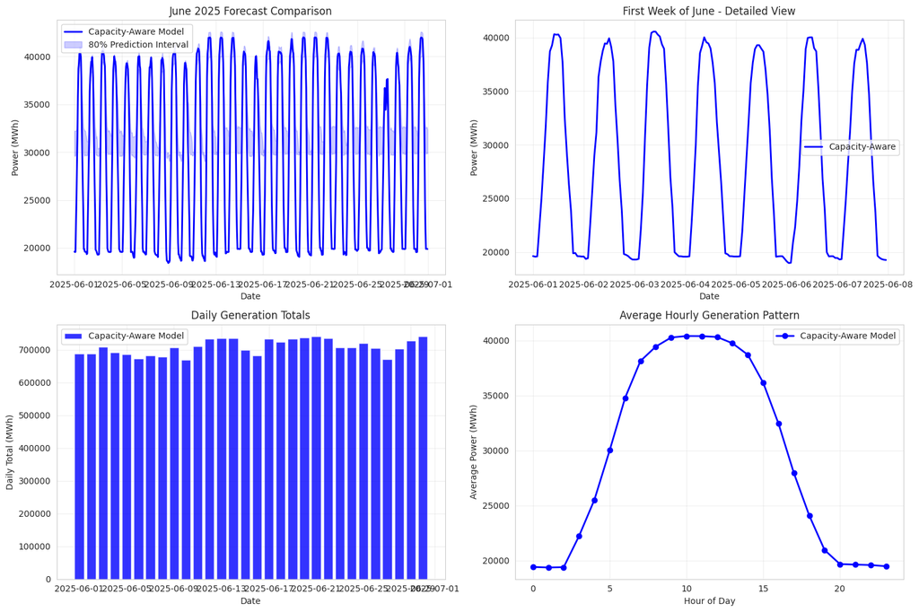

```python
# Load original forecast if available for comparison
original_forecast = None
if os.path.exists('../forecast_q1.csv'):
    original_forecast = pd.read_csv('../forecast_q1.csv')
    original_forecast['DateTime'] = pd.to_datetime(original_forecast['DateTime'])

fig, axes = plt.subplots(2, 2, figsize=(15, 10))

# Plot 1: Full month comparison
if original_forecast is not None:
    axes[0, 0].plot(original_forecast['DateTime'], original_forecast['power'],
                   'r-', alpha=0.7, linewidth=1, label='Original Model')

axes[0, 0].plot(june_forecast['DateTime'], june_forecast['power'],
               'b-', linewidth=2, label='Capacity-Aware Model')

# Add prediction intervals if available
if 'power_q10' in june_forecast.columns and 'power_q90' in june_forecast.columns:
    axes[0, 0].fill_between(june_forecast['DateTime'],
                           june_forecast['power_q10'],
                           june_forecast['power_q90'],
                           alpha=0.2, color='blue', label='80% Prediction Interval')

axes[0, 0].set_xlabel('Date')
axes[0, 0].set_ylabel('Power (MWh)')
axes[0, 0].set_title('June 2025 Forecast Comparison')
axes[0, 0].legend()
axes[0, 0].grid(True, alpha=0.3)

# Plot 2: First week detailed
first_week = june_forecast[:7*24]
if original_forecast is not None:
    first_week_orig = original_forecast[:7*24]
    axes[0, 1].plot(first_week_orig['DateTime'], first_week_orig['power'],
                   'r-', alpha=0.7, label='Original')

axes[0, 1].plot(first_week['DateTime'], first_week['power'],
               'b-', linewidth=2, label='Capacity-Aware')
axes[0, 1].set_xlabel('Date')
axes[0, 1].set_ylabel('Power (MWh)')
axes[0, 1].set_title('First Week of June - Detailed View')
axes[0, 1].legend()
axes[0, 1].grid(True, alpha=0.3)

# Plot 3: Daily totals
daily_totals = june_forecast.set_index('DateTime').resample('D')['power'].sum()

if original_forecast is not None:
    daily_orig = original_forecast.set_index('DateTime').resample('D')['power'].sum()
    axes[1, 0].bar(daily_orig.index, daily_orig.values, alpha=0.6,
                  color='red', label='Original Model')

axes[1, 0].bar(daily_totals.index, daily_totals.values, alpha=0.8,
              color='blue', label='Capacity-Aware Model')
axes[1, 0].set_xlabel('Date')
axes[1, 0].set_ylabel('Daily Total (MWh)')
axes[1, 0].set_title('Daily Generation Totals')
axes[1, 0].legend()
axes[1, 0].grid(True, alpha=0.3)

# Plot 4: Hourly average patterns
hourly_pattern = june_forecast.set_index('DateTime').groupby(lambda x: x.hour)['power'].mean()

if original_forecast is not None:
    hourly_orig = original_forecast.set_index('DateTime').groupby(lambda x: x.hour)['power'].mean()
    axes[1, 1].plot(hourly_orig.index, hourly_orig.values, 'ro-',
                   alpha=0.7, label='Original Model')

axes[1, 1].plot(hourly_pattern.index, hourly_pattern.values, 'bo-',
               linewidth=2, markersize=6, label='Capacity-Aware Model')
axes[1, 1].set_xlabel('Hour of Day')
axes[1, 1].set_ylabel('Average Power (MWh)')
axes[1, 1].set_title('Average Hourly Generation Pattern')
axes[1, 1].legend()
axes[1, 1].grid(True, alpha=0.3)

plt.tight_layout()
plt.show()

# Print final summary
if original_forecast is not None:
    print(f"\n🎯 FINAL COMPARISON SUMMARY:")
    print(f"Original model total: {original_forecast['power'].sum():,.0f} MWh")
    print(f"Capacity-aware total: {june_forecast['power'].sum():,.0f} MWh")
    print(f"Difference: {june_forecast['power'].sum() - original_forecast['power'].sum():,.0f} MWh")
    print(f"Percentage increase: {(june_forecast['power'].sum() / original_forecast['power'].sum() - 1)*100:.1f}%")

    print(f"\nThis addresses the structural capacity bias identified in the original submission!")
    print(f"The capacity-aware model accounts for Germany's ongoing solar expansion.")
```

## 12. Summary and Conclusions

### Key Improvements Implemented:

1. **✅ Capacity Growth Modeling**:
   - Exponential trend fitting to historical capacity
   - Year dummy variables for discrete capacity additions
   - Seasonal capacity scaling factors
2. **✅ Weighted Training Strategy**:
   - Recent data (2024-2025) gets exponentially higher weight
   - Reduces influence of outdated capacity levels from 2022-2023
3. **✅ Enhanced Feature Engineering**:
   - Time trend features (days since start, years since start)
   - Capacity utilization metrics
   - Growth rate indicators
4. **✅ Post-processing Adjustments**:
   - Multiplicative capacity adjustment for 2025 projections
   - Hour-specific and seasonal adjustment factors